# p8105_hw3_tem2171

Teresa Moore

2023-10-13

## Problem 2

This problem uses the BRFSS data. DO NOT include this dataset in your local data directory; instead, load the data from the p8105.datasets package using

```r
library(p8105.datasets)
data("brfss_smart2010")

library(tidyverse)
```

```r
library(dplyr)
library(ggplot2)
```

## Problem 2a

First, do some data cleaning:

format the data to use appropriate variable names; focus on the “Overall Health” topic

include only responses from “Excellent” to “Poor” organize responses as a factor taking levels ordered from “Poor” to “Excellent”

```r
response_order <- c("Poor", "Fair", "Good", "Very good", "Excellent")

overall_health_df <- brfss_smart2010 |>
  janitor::clean_names() |>
  filter(topic == "Overall Health") |>
  transform(response = factor(response, levels = response_order, ordered = TRUE))
```

## Problem 2b

Using this dataset, do or answer the following (commenting on the results of each):

In 2002, which states were observed at 7 or more locations? What about in 2010?

```r
#2002
states_2002 <- overall_health_df |>
  filter(year==2002) |>
  group_by(locationabbr) |>
  summarise(unique_locationdesc = n_distinct(locationdesc)) |>
  filter(unique_locationdesc >= 7)

#2010
states_2010 <- overall_health_df |>
  filter(year==2010) |>
  group_by(locationabbr) |>
  summarise(unique_locationdesc = n_distinct(locationdesc)) |>
  filter(unique_locationdesc >= 7)
```

There were 6 states that were observed at 7 or more locations in 2002. There were 14 states that were observed at 7 or more locations in 2010.

## Problem 2c

Construct a dataset that is limited to Excellent responses, and contains, year, state, and a variable that averages the data_value across locations within a state.

```r
excellent_overall_health_df <- overall_health_df |>
  filter(response == "Excellent") |>
  group_by(year, locationabbr) |>
  mutate(average_data_value = mean(data_value, na.rm = TRUE)) |>
  select(year, locationabbr, average_data_value)
```

## Problem 2d

Make a “spaghetti” plot of this average value over time within a state (that is, make a plot showing a line for each state across years – the geom_line geometry and group aesthetic will help).

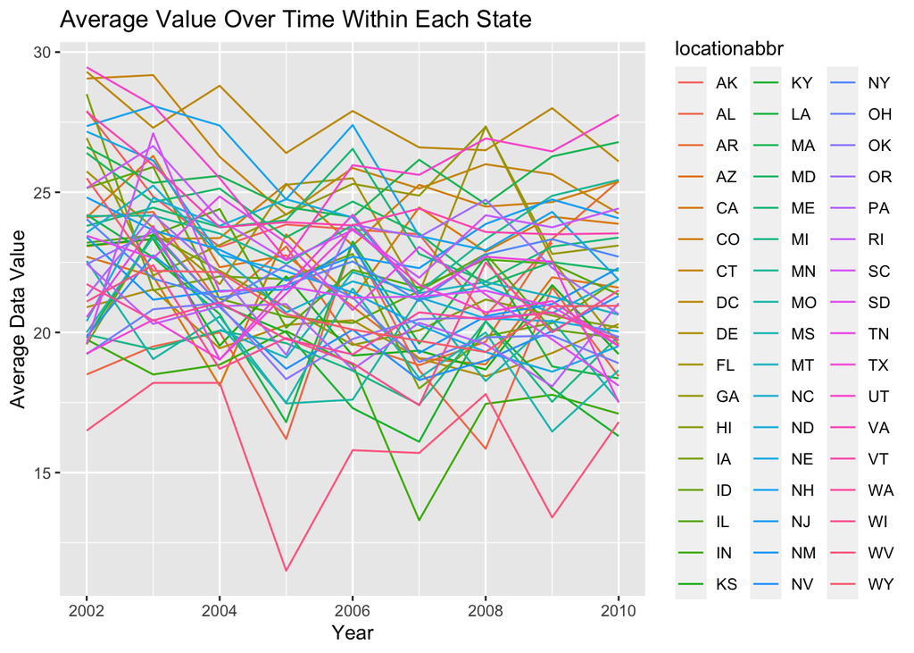

```r
ggplot(excellent_overall_health_df, aes(x = year, y = average_data_value, group = locationabbr, color = locationabbr)) +
  geom_line() +
  labs(title = "Average Value Over Time Within Each State",
       x = "Year",
       y = "Average Data Value")
```

## Problem 2e

Make a two-panel plot showing, for the years 2006, and 2010, distribution of data_value for responses (“Poor” to “Excellent”) among locations in NY State.

```r
ny_data <- overall_health_df |>
  filter(locationabbr == "NY" & year %in% c(2006, 2010)) |>
  separate(locationdesc, into = c("state", "county")) |>
  select(-state) |>
  group_by(county)
```

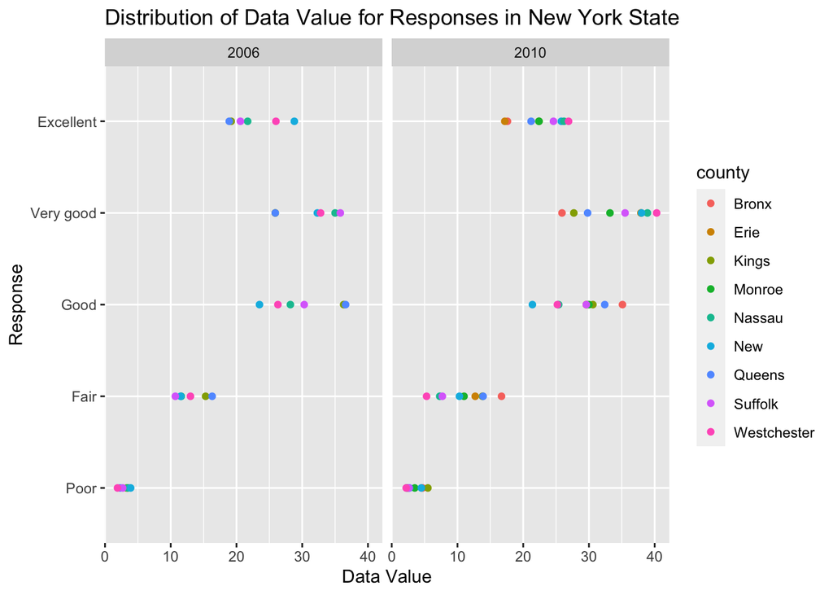

```r
ggplot(ny_data, aes(x = data_value, y = response)) +
  geom_point(aes(color = county)) +
  facet_grid(. ~ year) +
  labs(
    title = "Distribution of Data Value for Responses in New York State",
    x = "Data Value",
    y = "Response"
  )
```

## Problem 3

Accelerometers have become an appealing alternative to self-report techniques for studying physical activity in observational studies and clinical trials, largely because of their relative objectivity. During observation periods, the devices can measure MIMS in a short period; one-minute intervals are common. Because accelerometers can be worn comfortably and unobtrusively, they produce around-the-clock observations.

This problem uses accelerometer data collected on 250 participants in the NHANES study. The participants’ demographic data can be downloaded here, and their accelerometer data can be downloaded here. Variables *MIMS are the MIMS values for each minute of a 24-hour day starting at midnight.

```r
demo_df =
  read.csv(file = "data/nhanes_covar.csv") |>
  janitor::clean_names()

accelerometer_df =
  read.csv(file = "data/nhanes_accel.csv") |>
  janitor::clean_names()
```

## Problem 3a

Load, tidy, merge, and otherwise organize the data sets. Your final dataset should include all originally observed variables; exclude participants less than 21 years of age exclude those with missing demographic data encode data with reasonable variable classes (i.e. not numeric, and using factors with the ordering of tables and plots in mind).

```r
demo_df <- subset(demo_df, age>=21)
demo_df <- demo_df[complete.cases(demo_df), ]

merged_demo_accel <-
  left_join(demo_df, accelerometer_df, by = "seqn") |>
  mutate(
    education = case_match(
      education,
      1 ~ "less than HS",
      2 ~ "HS equivalent",
      3 ~ "more than HS"),
    education = as.factor(education)) |>
  mutate(
    sex = case_match(
      sex,
      1 ~ "male",
      2 ~ "female"),
    sex = as.factor(sex))
```

## Problem 3b

Produce a reader-friendly table for the number of men and women in each education category, and create a visualization of the age distributions for men and women in each education category. Comment on these items.

```r
merged_demo_accel |>
  group_by(sex, education) |>
  summarize (count=n()) |>
  knitr::kable()
```

[output not shown]

| sex | education | count |
| --- | --- | --- |
| female | HS equivalent | 23 |
| female | less than HS | 28 |
| female | more than HS | 59 |
| male | HS equivalent | 35 |
| male | less than HS | 27 |
| male | more than HS | 56 |

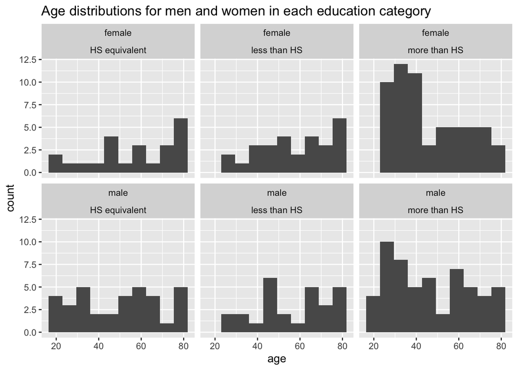

```r
merged_demo_accel |>
  ggplot(aes(x=age)) +
  geom_histogram(bins=10) +
  facet_wrap(sex~education) +
  labs(title = "Age distributions for men and women in each education category")
```

The education category for both genders with the highest count is more than HS(females:59, males:56). The lowest count for females is HS equivalent (23), while the lowest count for males is less than HS(27).

For females, the distribution in the more than HS category, is right skewed, meaning that on average they are younger, or below 40. For males, in the more than HS category, similarly to females it is right skewed, but it is less of an intense skew. The other two categories are slightly left skewed, but only very slightly, meaning that there are more older females in the less than HS and HS equivalent categories. For the other two male categories, there is no real skewness.

## Problem 3c

Traditional analyses of accelerometer data focus on the total activity over the day. Using your tidied dataset, aggregate across minutes to create a total activity variable for each participant

```r
total_activity_df <- merged_demo_accel |>
  mutate(
    total_activity = rowSums(across(c(min1:min1440))
  ))
```

## Problem 3d

Plot these total activities (y-axis) against age (x-axis); your plot should compare men to women and have separate panels for each education level. Include a trend line or a smooth to illustrate differences. Comment on your plot.

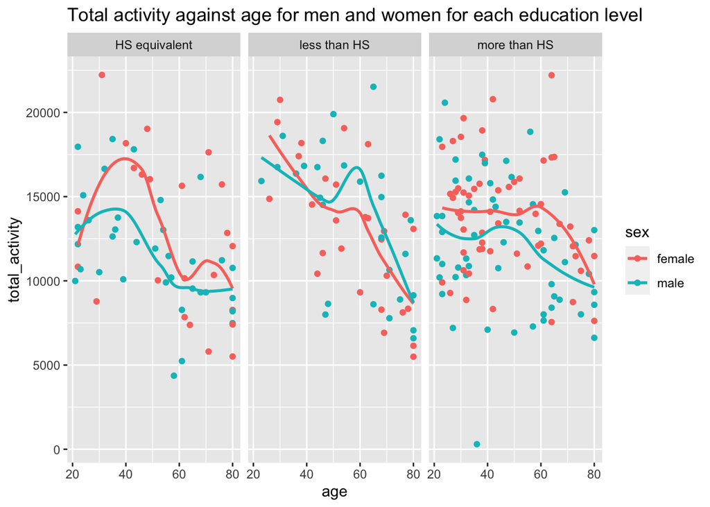

```r
ggplot(total_activity_df, aes(x = age, y = total_activity, color=sex)) +
  geom_point() +
  geom_smooth(se=FALSE) +
  facet_wrap(~ education) +
  labs(title = "Total activity against age for men and women for each education level")
```

In general, the total activity against age for men and women for each education level decreases, or as age increases, in each education category, the total activity level decreases on average. For HS equivalent and more than HS, females on average had higher activity levels, while for less than high school, males have higher levels.

## Problem 3e

Accelerometer data allows the inspection activity over the course of the day. Make a three-panel plot that shows the 24-hour activity time courses for each education level and use color to indicate sex.

[figure not shown]

```r
day_activity_time = total_activity_df |>
  pivot_longer(
    min1:min1440,
    names_to = "minute",
    values_to = "activity"
    )

day_activity_time |>
  ggplot(aes(x=minute, y=activity, color=sex)) +
  geom_point(alpha=0.25, size=0.1) +
  geom_smooth() +
  facet_wrap(.~education) +
  labs(title = "24-hour activity time course by education level and sex")
```

Describe in words any patterns or conclusions you can make based on this graph; including smooth trends may help identify differences.

All three panels have similar shapes to them, with a dip in activity levels around the same time.